# Linear Regression

Cheryn Aouaj, Lisa Bebell, Sun Kim, Manasi Mohan

12/13/2020

```r
library(readr)
library(dplyr)
library(lubridate)
library(ggplot2)
library(caret)
```

We will first use linear regression (ordinary least squares) to explore the association between water temperature and number of unique fish species. As we have water temperature data at two depths, 2m and 9m, we will fit two linear regression models. We will begin by splitting our data into a training (60%) and testing set (40%).

```r
# read data
setwd("cleaned_data")
temp <- read_csv("aims_temperatures.csv")
fish <- read_csv("fish_species_counts.csv")
fish_temp <- merge(x=temp, y=fish, by="date")

# split into train and test
set.seed(123)
train_index <- createDataPartition(y=fish_temp$num_of_species, times=1, p = 0.6, list=FALSE)

train_set <- fish_temp[train_index, ]
test_set <- fish_temp[-train_index, ]
```

```r
# fit lm for 2m depth
fish_temp_2.0m <- lm(num_of_species ~ avg_water_temp_2.0m_flat_site, data=train_set)
summary(fish_temp_2.0m)
```

```
##
## Call:
## lm(formula = num_of_species ~ avg_water_temp_2.0m_flat_site,
##     data = train_set)
##
## Residuals:
##     Min      1Q  Median      3Q     Max
## -54.397  -8.987   1.300  10.646  39.227
##
## Coefficients:
##                               Estimate Std. Error t value Pr(>|t|)
## (Intercept)                   131.0809    18.3488   7.144 1.59e-11 ***
## avg_water_temp_2.0m_flat_site  -2.5211     0.6673  -3.778 0.000208 ***
## ---
## Signif. codes:  0 '***' 0.001 '**' 0.01 '*' 0.05 '.' 0.1 ' ' 1
##
## Residual standard error: 15.6 on 203 degrees of freedom
## Multiple R-squared:  0.06569,    Adjusted R-squared:  0.06109
## F-statistic: 14.27 on 1 and 203 DF,  p-value: 0.0002078
```

```r
# fit lm for 9m depth
fish_temp_9.0m <- lm(num_of_species ~ avg_water_temp_9.0m_slope_site, data=train_set)
summary(fish_temp_9.0m)
```

```
##
## Call:
## lm(formula = num_of_species ~ avg_water_temp_9.0m_slope_site,
##     data = train_set)
##
## Residuals:
##     Min      1Q  Median      3Q     Max
## -54.215  -8.575   1.727  10.459  39.694
##
## Coefficients:
##                                Estimate Std. Error t value Pr(>|t|)
## (Intercept)                    134.8931    18.6599   7.229 9.69e-12 ***
## avg_water_temp_9.0m_slope_site  -2.6717     0.6817  -3.919 0.000121 ***
## ---
## Signif. codes:  0 '***' 0.001 '**' 0.01 '*' 0.05 '.' 0.1 ' ' 1
##
## Residual standard error: 15.56 on 203 degrees of freedom
## Multiple R-squared:  0.07035,    Adjusted R-squared:  0.06577
## F-statistic: 15.36 on 1 and 203 DF,  p-value: 0.0001214
```

We see that the models are very similar in results. The first model suggests that a 1-degree-Celsius increase in water temperature at 2m is associated with an average reduction of 2.5 fish species in a month. The second model suggests that a 1-degree-Celsius increase in water temperature at 9m is associated with an average reduction of 2.7 fish species in a month.

Although we do not expect a major difference in the performance of these two models, we will compare the accuracy of each to assess whether water temperature at 2m or 9m is a better predictor of unique fish species observed in the Great Barrier Reef.

```r
pred_2.0m <- predict(fish_temp_2.0m, test_set)
pred_9.0m <- predict(fish_temp_9.0m, test_set)

postResample(pred = pred_2.0m, obs = test_set$num_of_species)
```

```
##      RMSE  Rsquared       MAE
## 14.499953  0.090049 11.165851
```

```r
postResample(pred = pred_9.0m, obs = test_set$num_of_species)
```

```
##        RMSE    Rsquared         MAE
## 14.49988646  0.08987795 11.16910801
```

As expected, results are very similar. The root mean-squared errors are almost identical, suggesting that 2m and 9m water temperatures predict number of species equally well. We can assess this visually to confirm our results.

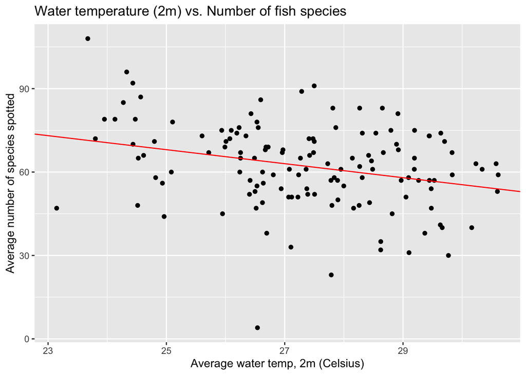

```r
# water temp at 2.0m
test_set %>%
  ggplot(aes(avg_water_temp_2.0m_flat_site, num_of_species)) +
  geom_point() +
  geom_abline(intercept=fish_temp_2.0m$coefficients[1], slope=fish_temp_2.0m$coefficients[2], col="red") +
  xlab("Average water temp, 2m (Celsius)") +
  ylab("Average number of species spotted") +
  ggtitle("Water temperature (2m) vs. Number of fish species")
```

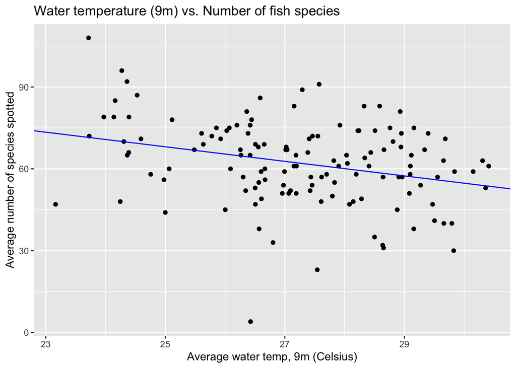

```r
# water temp at 9.0m
test_set %>%
  ggplot(aes(avg_water_temp_9.0m_slope_site, num_of_species)) +
  geom_point() +
  geom_abline(intercept=fish_temp_9.0m$coefficients[1], slope=fish_temp_9.0m$coefficients[2], col="blue") +
  xlab("Average water temp, 9m (Celsius)") +
  ylab("Average number of species spotted") +
  ggtitle("Water temperature (9m) vs. Number of fish species")
```

Not only do the distributions of points look very similar, but so do the slopes of the regression lines at the two depths. We can conclude that water temperature at 2m and 9m have the same predictive power for the number of fish species. As we see from the graphs, this is likely because the ranges of temperatures are very similar at the two depths.

### Conclusions

We found that increased water temperature was associated with a decrease in the number of unique fish species recorded in the Great Barrier Reef from 1997 to 2011. The effect of temperature was similar at different depths of 2.0m and 9.0m. Although these models do not adjust for potential confounders, they suggest an inverse linear relationship between water temperature and fish species diversity. This finding supports the negative effects of global warming on coral reef animal diversity, with the caveat that fish species diversity could have changed over time due to many other changes occurring during the same time period, including water pollution, commercial and private fishing activity, and other environmental effects not accounted for in our simplified models.